# Analysis of scRNA-seq data of NP-specific GC B cells at 13dpi

Dianyu Chen

2021/4/6

In our experiment, we immunized 2 WT B6 mice separately with NP-KLH+LPS+Alumn, sacrificed at 13dpi, and NP-specific GC B cells were sorted to load 10X 5’ scRNA-seq. Raw Fastq files were processed by CellRanger (v3.1.0) with default parameters:

```
## e.g.
## GEX
/xx/software/cellranger-3.1.0/cellranger count --id=GCB_NP_mRNA_result \
    --transcriptom=/xx/reference/10x/refdata-cellranger-mm10-3.0.0 \
    --fastqs=/xx/GCB_NP/5_mRNA
```

We got count matrix output from CellRanger, then loaded them into R (v3.6.1) and performed downstream analysis with Seurat (v3.1.0).  
Firstly, load the packages needed and define the function to read in CellRanger output:

```r
library(Seurat)
library(Matrix)
library(tidyverse)
library(Matrix.utils)

read_10x_matrix <- function(matrix_dir, project_id){
    barcode.path <- paste0(matrix_dir, "barcodes.tsv.gz")
    features.path <- paste0(matrix_dir, "features.tsv.gz")
    matrix.path <- paste0(matrix_dir, "matrix.mtx.gz")
    mat <- readMM(file = matrix.path)
    feature.names = read.delim(features.path,
                               header = FALSE,
                               stringsAsFactors = FALSE)
    barcode.names = read.delim(barcode.path,
                               header = FALSE,
                               stringsAsFactors = FALSE)
    colnames(mat) = barcode.names$V1
    rownames(mat) = feature.names$V2
    ## some ensembl gene ids correspond to same gene symbol
    ## thus we combine these rows
    mat <- aggregate.Matrix(mat, rownames(mat), FUN="sum")
    seurat_object <- CreateSeuratObject(counts = mat,
                                        project = project_id,
                                        min.cells = 3,
                                        min.features = 200)
    return(seurat_object)
}
```

After finishing all the preparations, read the count matrix file:

```r
gcb_np_batch1 <- read_10x_matrix("../data/filtered_feature_bc_matrix_np_batch1/",
                                 "gcb_np_batch1")
gcb_np_batch2 <- read_10x_matrix("../data/filtered_feature_bc_matrix_np_batch2/",
                                 "gcb_np_batch2")
```

Then perform QC and integrate 2 batches of data:

```r
## Integrate two batches
gcb_np_list <- list(gcb_np_batch1, gcb_np_batch2)
cell_prefix_gcb_np <- c("gcb_np_batch1", "gcb_np_batch2")
for (i in 1:length(gcb_np_list)) {
    gcb_np_list[[i]] <- RenameCells(gcb_np_list[[i]],
                                     add.cell.id = cell_prefix_gcb_np[i])
    gcb_np_list[[i]][["percent.mt"]] <- PercentageFeatureSet(gcb_np_list[[i]],
                                                             pattern = "^mt-")
    gcb_np_list[[i]] <- subset(gcb_np_list[[i]],
                                subset = nFeature_RNA > 500 & nCount_RNA < 20000 & percent.mt < 10)
    gcb_np_list[[i]] <- NormalizeData(gcb_np_list[[i]],
                                      verbose = FALSE)
    gcb_np_list[[i]] <- FindVariableFeatures(gcb_np_list[[i]],
                                             selection.method = "vst",
                                              nfeatures = 2000,
                                             verbose = FALSE)
}

gcb_np_anchors <- FindIntegrationAnchors(object.list = gcb_np_list,
                                         dims = 1:30)
gcb_np_integrated <- IntegrateData(anchorset = gcb_np_anchors,
                                    dims = 1:30)
```

After integration, perform scaling and linear dimensional reduction:

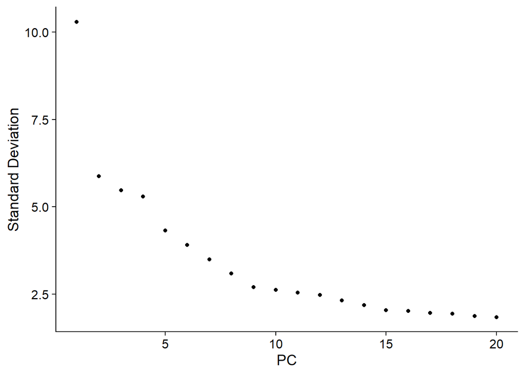

```r
DefaultAssay(gcb_np_integrated) <- "integrated"
gcb_np_integrated <- ScaleData(gcb_np_integrated)
gcb_np_integrated <- RunPCA(gcb_np_integrated,
                            features = VariableFeatures(object = gcb_np_integrated))
ElbowPlot(gcb_np_integrated)
```

Based on the Elbow plot, we choose 15 PCs for further non-linear dimensional reduction and clustering:

```r
gcb_np_integrated <- FindNeighbors(gcb_np_integrated, dims = 1:15)
gcb_np_integrated <- FindClusters(gcb_np_integrated, resolution = 0.2)
```

```
## Modularity Optimizer version 1.3.0 by Ludo Waltman and Nees Jan van Eck
##
## Number of nodes: 4247
## Number of edges: 152493
##
## Running Louvain algorithm...
## Maximum modularity in 10 random starts: 0.9002
## Number of communities: 7
## Elapsed time: 0 seconds
```

```r
gcb_np_integrated <- RunUMAP(gcb_np_integrated, dims = 1:15)
```

So, finally 4247 cells remained, divided into 7 clusters, without significant batch effects:

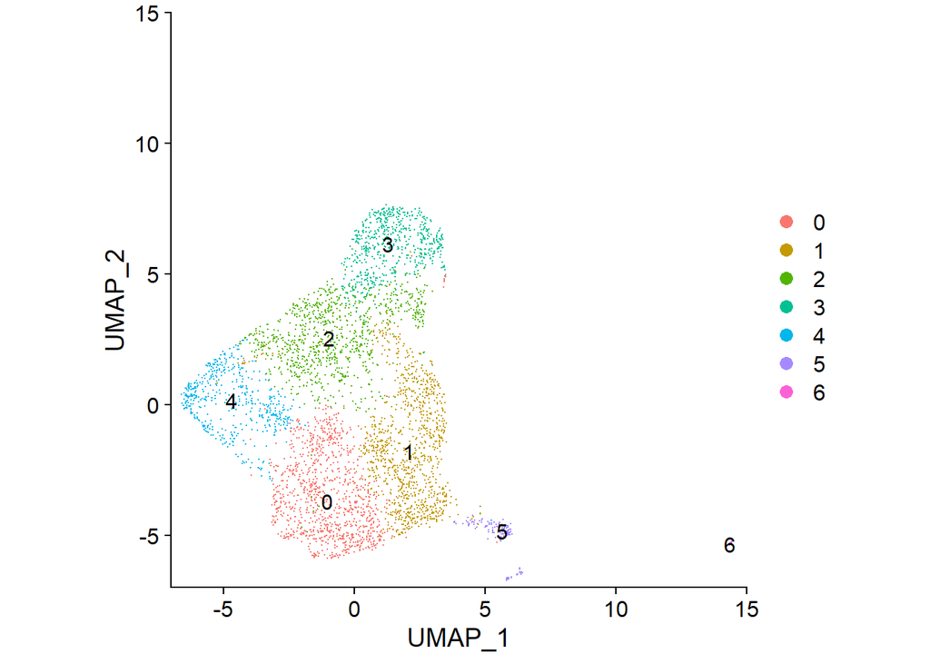

```r
## group by cluster
DimPlot(gcb_np_integrated,
        pt.size = 0.01,
        label = T) +
    coord_equal(expand = FALSE)+
    lims(x=c(-7,15), y=c(-7,15))
```

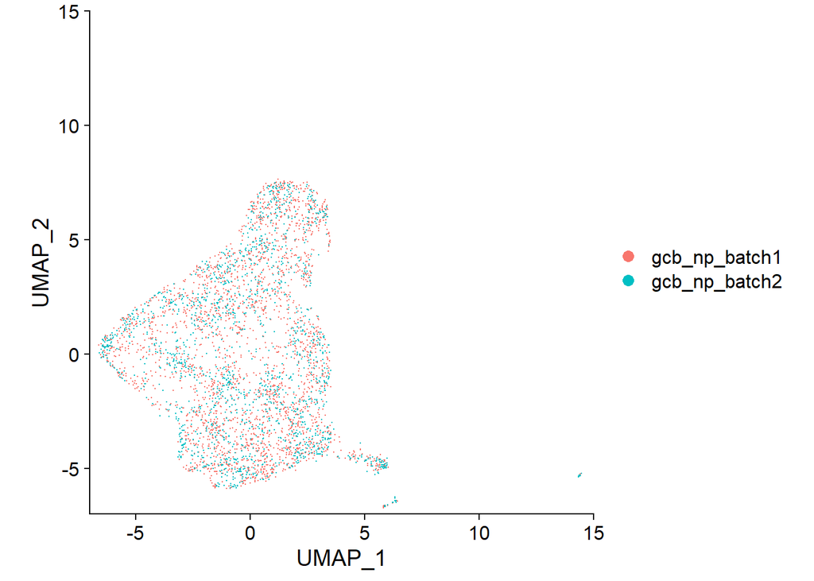

```r
## group by mouse
DimPlot(gcb_np_integrated,
        group.by = "orig.ident",
        pt.size = 0.01) +
    coord_equal(expand = FALSE)+
    lims(x=c(-7,15), y=c(-7,15))
```

Based on the clustering result, we perform DEG analysis on each cluster:

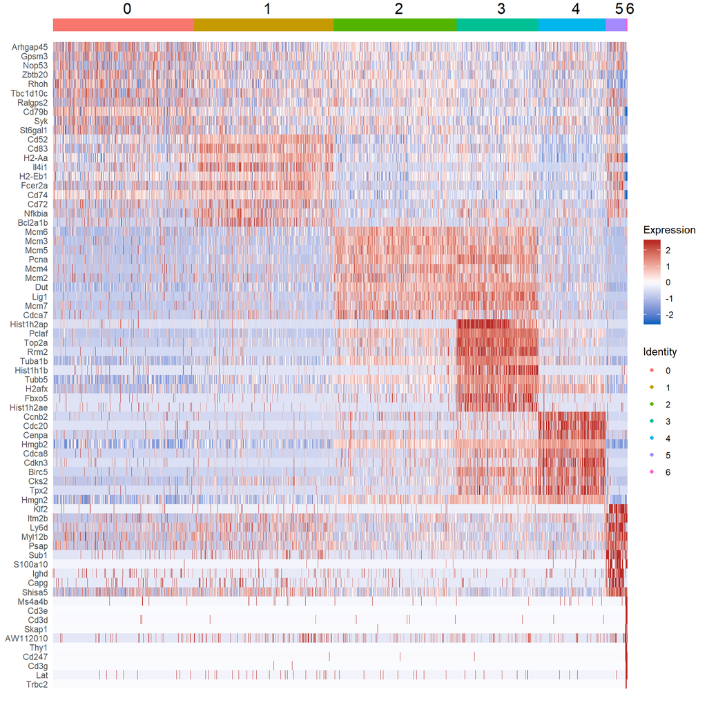

```r
## change assay to orignal data
DefaultAssay(gcb_np_integrated) <- "RNA"
gcb_np_integrated <- ScaleData(gcb_np_integrated)
gcb_np_integrated$orig.ident <- factor(gcb_np_integrated$orig.ident)
gcb_np_integrated.markers <- FindAllMarkers(gcb_np_integrated,
                                             test.use = "MAST",
                                             only.pos = TRUE,
                                             min.pct = 0.25,
                                             logfc.threshold = 0.25,
                                             latent.vars = "orig.ident")
top10_gcb_np_integrated <- gcb_np_integrated.markers %>%
    group_by(cluster) %>%
    arrange(p_val_adj) %>%
    slice(1:10)
DoHeatmap(gcb_np_integrated,
          features = top10_gcb_np_integrated$gene,
          angle = 0,
          draw.lines = FALSE) +
    scale_fill_gradientn(colors = c("#1565C0", "white", "#b92b27"))
```

According to the marker genes of each cluster, we find that cluster 6 is T cell, thus exclude them in downstream analysis.

```r
gcb_np_integrated_clean <- subset(gcb_np_integrated,
                                  seurat_clusters %in% 0:5)
```